# Практична робота №4

## Тема:

### Тема. Алгоритми пошуку та їх складність

## Мета:

### Опанувати основні алгоритми сортування та навчитись методам аналізу їх асимптотичної складності

## 1) Оцінити асимптотичну складність алгоритму лінійного пошуку у 𝑂-нотації в найгіршому і в найкращому випадку. Як можна покращити алгоритм лінійного пошуку?

# Асимптотична складність алгоритму лінійного пошуку

### Оцінка асимптотичної складності алгоритму лінійного пошуку

#### 1. Найкращий випадок

- У найкращому випадку шуканий елемент знаходиться на початку списку, тому виконується лише одна перевірка.
- Часова складність: $$ O(1) $$

#### 2. Найгірший випадок

- У найгіршому випадку:
  - Шуканий елемент розташований у кінці списку, або
  - Шуканого елемента немає у списку, і перевіряються всі $n$ елементів.
- Часова складність: $$ O(n) $$

### Як можна покращити алгоритм лінійного пошуку?

1. **Використання впорядкованості даних**:
   - Якщо список впорядкований, пошук можна припинити, коли знайдено елемент більший за шуканий.
   - Наприклад, для списку $\{1, 3, 5, 7, 9\}$ при пошуку $4$ алгоритм зупиняється на $5$, замість перевірки всього списку.
2. **Додавання "вартового" елемента**:
   - Додайте в кінець списку "вартовий" елемент, рівний шуканому значенню.
   - Це усуває необхідність перевіряти вихід за межі списку.
   - Наприклад, для списку $\{2, 4, 6, 8\}$ і пошуку $5$ додається вартовий елемент $5$: $\{2, 4, 6, 8, 5\}$.
3. **Паралелізація пошуку**:
   - Для великих наборів даних розділіть список на кілька частин і шукайте одночасно у кожній частині за допомогою багатопоточності.
   - Наприклад, список $\{1, 2, 3, 4, 5, 6, 7, 8, 9, 10\}$ розділяється на дві частини $\{1, 2, 3, 4, 5\}$ і $\{6, 7, 8, 9, 10\}$.
4. **Перехід до ефективніших алгоритмів пошуку**:
   - Для впорядкованих списків використовуйте **бінарний пошук** із складністю $O(\log n)$.
   - Для великих даних застосовуйте **хеш-таблиці**, де середня складність пошуку дорівнює $O(1)$.
5. **Індексація**:
   - Використовуйте індексацію, як у базах даних, для пришвидшення пошуку.
   - Наприклад, створіть індекс для списку $\{10, 20, 30, 40\}$, щоб швидко знайти елемент $30$.

## 2) Оцінити асимптотичну складність алгоритму бінарного пошуку у 𝑂-нотації в найгіршому і в найкращому випадку.

### Алгоритм **бінарного пошуку** використовується для пошуку елемента в упорядкованому масиві шляхом багаторазового ділення простору пошуку навпіл.

## Складність у $O$-нотації

### Найгірший випадок

У найгіршому випадку шуканий елемент відсутній у масиві, або він знаходиться в такій позиції, що вимагає максимальну кількість поділів. Кожного разу кількість елементів для перевірки зменшується вдвічі.

Кількість ітерацій визначається рівнянням: $$ n \to \frac{n}{2} \to \frac{n}{4} \to \dots \to 1 $$

Це відповідає $k$ ітераціям, де: $$ \frac{n}{2^k} = 1 \implies k = \log_2 n $$

Таким чином, асимптотична складність у найгіршому випадку: $$ O(\log n) $$

### Найкращий випадок

У найкращому випадку шуканий елемент знаходиться на середній позиції масиву вже при першій перевірці. Тобто виконується лише одна операція перевірки.

Асимптотична складність у найкращому випадку: $$ O(1) $$

## 3) Побудувати алгоритм тернарного пошуку і оцінити його асимптотичну складність алгоритму у 𝑂-нотації в найгіршому і в найкращому випадку. Який з алгоритмів є оптимальнішим: бінарний, чи тернарний? Обґрунтувати відповідь відповідними обчисленнями.

# Алгоритм тернарного пошуку та оцінка його складності

## Алгоритм тернарного пошуку

Тернарний пошук застосовується для пошуку елемента в упорядкованому масиві шляхом ділення простору пошуку на три частини. Його ідея:

1. Упорядкований масив поділяється на три частини за двома індексами:
   - Перший індекс: $m_1 = \lfloor l + \frac{r-l}{3} \rfloor$
   - Другий індекс: $m_2 = \lfloor r - \frac{r-l}{3} \rfloor$
2. Елемент, що шукається, порівнюється з елементами на позиціях $m_1$ та $m_2$:
   - Якщо шуканий елемент дорівнює $A[m_1]$, повертається $m_1$.
   - Якщо шуканий елемент дорівнює $A[m_2]$, повертається $m_2$.
   - Якщо елемент менший за $A[m_1]$, пошук продовжується в лівій частині $[l, m_1 - 1]$.
   - Якщо елемент більший за $A[m_2]$, пошук продовжується в правій частині $[m_2 + 1, r]$.
   - В іншому випадку пошук відбувається в середній частині $[m_1 + 1, m_2 - 1]$.
3. Процес повторюється, поки індекси $l$ та $r$ не співпадуть.

## Асимптотична складність тернарного пошуку

### Найгірший випадок

У найгіршому випадку тернарний пошук виконує $k$ ітерацій, де на кожній ітерації кількість елементів зменшується до $\frac{1}{3}$ від попередньої.

Кількість ітерацій визначається рівнянням: $$ n \to \frac{n}{3} \to \frac{n}{9} \to \dots \to 1 $$

Це відповідає $k$ ітераціям, де: $$ \frac{n}{3^k} = 1 \implies k = \log_3 n $$

Таким чином, асимптотична складність у найгіршому випадку: $$ O(\log n) $$

### Найкращий випадок

У найкращому випадку шуканий елемент збігається з $A[m_1]$ або $A[m_2]$ на першій ітерації. Це вимагає лише однієї операції перевірки.

Асимптотична складність у найкращому випадку: $$ O(1) $$

## Порівняння тернарного та бінарного пошуків

Кількість ітерацій для бінарного пошуку: $$ \log_2 n $$

Кількість ітерацій для тернарного пошуку: $$ \log_3 n = \frac{\log_2 n}{\log_2 3} $$

## 4) Порівняти ефективність алгоритмів лінійного, бінарного та тернарного пошуку для різних розмірів вхідного списку. Для цього провести експериментальне дослідження та побудувати графіки залежності часу виконання алгоритму від розміру вхідного списку.

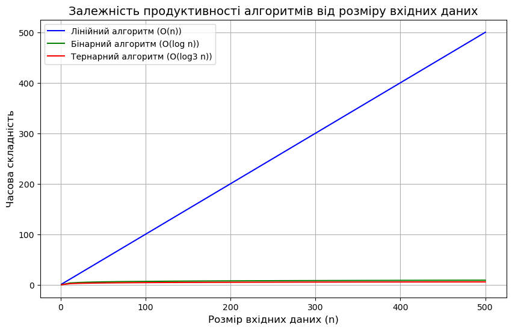

```python
import numpy as np
import matplotlib.pyplot as plt

# Input size (n)
n = np.linspace(1, 500)

# Time complexities
linear = n  # O(n)
binary = np.log2(n)  # O(log n)
ternary = np.log(n) / np.log(3)  # O(log3 n)

# Plotting
plt.figure(figsize=(10, 6))
plt.plot(n, linear, label="Лінійний алгоритм (O(n))", color="blue")
plt.plot(n, binary, label="Бінарний алгоритм (O(log n))", color="green")
plt.plot(n, ternary, label="Тернарний алгоритм (O(log3 n))", color="red")
plt.title("Залежність продуктивності алгоритмів від розміру вхідних даних", fontsize=14)
plt.xlabel("Розмір вхідних даних (n)", fontsize=12)
plt.ylabel("Часова складність", fontsize=12)
plt.legend(fontsize=10)
plt.grid(True)
plt.show()
```

### Аналіз ефективності алгоритмів пошуку

## Лінійний пошук:

Час виконання зростає лінійно зі збільшенням розміру списку. Найменш ефективний для великих списків, оскільки його складність $O(n)$.

## 5) Порівняти алгоритми пошуку за їхньою здатністю працювати з відсортованими та не відсортованими списками. Провести аналіз впливу відсортованості списку на час виконання кожного алгоритму.

# Порівняння алгоритмів пошуку: відсортовані та невідсортовані списки

Алгоритми пошуку мають різну ефективність залежно від стану списку: чи є він відсортованим, чи ні. Розглянемо кожен алгоритм окремо.

## Лінійний пошук

**Опис:** Лінійний пошук перевіряє всі елементи послідовно, тому його продуктивність не залежить від відсортованості списку.

- **Для невідсортованих списків:**  
  Лінійний пошук працює без змін, оскільки він не використовує жодної інформації про порядок елементів.  
  **Часова складність:** $O(n)$
- **Для відсортованих списків:**  
  Відсортованість списку не покращує роботу лінійного пошуку, оскільки він все одно перебирає елементи один за одним.  
  **Часова складність:** $O(n)$

## Бінарний пошук

**Опис:** Бінарний пошук застосовує стратегію поділу списку навпіл на кожній ітерації, що значно підвищує ефективність, але вимагає відсортованого списку.

- **Для невідсортованих списків:**  
  Бінарний пошук не може працювати без попереднього сортування списку. Сортування додає додаткову складність $O(n \log n)$.  
  **Загальна складність (сортування + пошук):** $O(n \log n)$
- **Для відсортованих списків:**  
  Бінарний пошук демонструє високу ефективність завдяки логарифмічному часу виконання.  
  **Часова складність:** $O(\log n)$

## Тернарний пошук

**Опис:** Тернарний пошук поділяє список на три частини замість двох, як це робить бінарний пошук.

- **Для невідсортованих списків:**  
  Як і бінарний пошук, тернарний пошук вимагає відсортованого списку. Попереднє сортування додає складність $O(n \log n)$.  
  **Загальна складність (сортування + пошук):** $O(n \log n)$
- **Для відсортованих списків:**  
  Тернарний пошук працює подібно до бінарного, але розбиває список на три частини, що в теорії може зменшити кількість ітерацій. Однак на практиці через додаткові порівняння продуктивність часто не перевершує бінарний пошук.  
  **Часова складність:** $O(\log n)$

## Вплив відсортованості списку на продуктивність

| **Алгоритм** | **Невідсортовані списки** | **Відсортовані списки** |
| --- | --- | --- |
| **Лінійний пошук** | $O(n)$ | $O(n)$ |
| **Бінарний пошук** | $O(n \log n)$ (сортування) | $O(\log n)$ |
| **Тернарний пошук** | $O(n \log n)$ (сортування) | $O(\log n)$ |

### Висновок:

1. **Лінійний пошук** залишається універсальним, але його продуктивність не покращується на відсортованих списках.
2. **Бінарний пошук** та **тернарний пошук** значно ефективніші на відсортованих списках, досягаючи складності $O(\log n)$.
3. Для невідсортованих списків додаткові витрати на сортування роблять бінарний і тернарний пошук менш ефективними порівняно з лінійним.

Таким чином, вибір алгоритму пошуку залежить від стану списку та необхідної продуктивності.

## 6) Розглянути сценарії використання кожного з алгоритмів пошуку у практичних задачах і обґрунтувати вибір кожного алгоритму в конкретному випадку

# Сценарії використання алгоритмів пошуку

## 1. Лінійний пошук

**Сценарії застосування:**

- Оптимальний для **невеликих списків** або даних, які **не відсортовані**.
- Використовується у випадках, коли забезпечити сортування неможливо або недоцільно, наприклад, при роботі з динамічними базами даних без індексів.
- Підходить для задач, де **пошук виконується одноразово** або кількість елементів у списку є невеликою.

**Причини вибору:**  
Лінійний пошук — це простий і універсальний метод. Його часова складність $O(n)$ робить його доцільним для невеликих списків або ситуацій, коли сортування не є необхідним. Його ключова перевага полягає у відсутності вимог до попереднього впорядкування даних.

## 2. Бінарний пошук

**Сценарії застосування:**

- Ідеально підходить для **відсортованих списків**, які змінюються рідко або не змінюються взагалі.
- Використовується в задачах із великою кількістю пошуків в **індексованих структурах**, таких як бази даних чи пошукові системи.
- Ефективний для **відсортованих масивів** і **бінарних дерев**, які дозволяють застосовувати стратегію поділу на половини.

**Причини вибору:**  
Завдяки часовій складності $O(\log n)$, бінарний пошук забезпечує значно вищу продуктивність порівняно з лінійним пошуком, особливо для великих обсягів даних. Це робить його основним інструментом для ефективного пошуку у впорядкованих структурах.

## 3. Тернарний пошук

**Сценарії застосування:**

- Використовується для **відсортованих списків**, коли розділення на **три частини** може сприяти додатковій оптимізації.
- Корисний у задачах, де **зменшення кількості порівнянь** є критичним, наприклад, коли кожне порівняння є ресурсомістким.
- Може бути застосований у **оптимізаційних задачах**, де важливо мінімізувати кількість ітерацій або операцій.

**Причини вибору:**  
Хоча тернарний пошук теоретично пропонує зменшення кількості ітерацій завдяки поділу списку на три частини, на практиці його переваги над бінарним пошуком є мінімальними через додаткові операції порівняння. Однак у деяких випадках він може бути ефективним для специфічних задач, де вартість одного порівняння є дуже високою.

## Обґрунтування вибору алгоритму в практичних задачах

- **Лінійний пошук** підходить для малих списків або невідсортованих даних, коли пошук виконується рідко або одноразово.
- **Бінарний пошук** є найкращим вибором для великих відсортованих списків, особливо коли пошук потрібно виконувати багаторазово.
- **Тернарний пошук** може бути корисним для відсортованих списків у випадках, де важливо мінімізувати кількість ітерацій, але його практичні переваги не завжди суттєві у порівнянні з бінарним пошуком.

# Контрольні питання

## 1) Що таке алгоритм пошуку і чому він важливий у контексті комп'ютерних наук?

# Алгоритми пошуку: Основні поняття та принципи

## 1. Що таке алгоритм пошуку і чому він важливий у контексті комп'ютерних наук?

**Алгоритм пошуку** — це набір інструкцій або кроків, які використовуються для **знаходження певного елемента** у структурі даних (масиві, списку, дереві тощо). Пошук може здійснюватися за ключовим значенням, індексом або іншими критеріями.

**Важливість у комп'ютерних науках:**

- Алгоритми пошуку є **основою** для багатьох завдань у програмуванні та обробці даних.
- Вони застосовуються у **пошукових системах**, базах даних, алгоритмах сортування, навігації графами та багатьох інших структурах даних.
- Ефективний алгоритм пошуку дозволяє значно зменшити **час обчислень** та оптимізувати використання **ресурсів** комп'ютера, що критично для роботи зі **великими обсягами даних**.

## 2) Які основні критерії оцінки ефективності алгоритмів пошуку?

## 2. Які основні критерії оцінки ефективності алгоритмів пошуку?

Оцінка алгоритмів пошуку здійснюється на основі таких критеріїв:

- **Часова складність**:  
  Визначає, скільки кроків виконує алгоритм для знаходження елемента в залежності від кількості даних $n$. Основні категорії складності:
  - $O(1)$ — константний час
  - $O(\log n)$ — логарифмічний час
  - $O(n)$ — лінійний час
  - $O(n \log n)$ та більше — для складніших алгоритмів
- **Просторова складність**:  
  Оцінка додаткової пам'яті, необхідної для роботи алгоритму.
- **Випадок найгіршої складності (Worst-case)**:  
  Максимальна кількість кроків, які може виконати алгоритм у найгіршому сценарії.
- **Випадок середньої складності (Average-case)**:  
  Очікувана продуктивність алгоритму у звичайних умовах.
- **Стійкість до зміни даних**:  
  Деякі алгоритми вимагають попереднього сортування даних, що впливає на їхню продуктивність.

## 3) Що таке лінійний пошук, і як він працює?

## 3. Що таке лінійний пошук і як він працює?

### Лінійний пошук

**Опис:**  
Лінійний пошук — це простий алгоритм, який послідовно перевіряє кожен елемент списку до тих пір, поки не знайде потрібний елемент або не досягне кінця списку.

### Як він працює:

1. Починаючи з першого елемента списку, порівнюємо кожен елемент зі значенням, яке потрібно знайти.
2. Якщо елемент збігається з цільовим значенням, алгоритм повертає **індекс** цього елемента.
3. Якщо список закінчився і елемент не знайдено, алгоритм повертає результат "не знайдено".

### Псевдокод:

```
def linear_search(arr, target):
    for i in range(len(arr)):
        if arr[i] == target:
            return i  # Повертаємо індекс знайденого елемента
    return -1  # Елемент не знайдено
```

## 4) Які умови повинні бути виконані для успішного застосування бінарного пошуку?

### 4. Умови успішного застосування бінарного пошуку

Бінарний пошук є ефективним алгоритмом, проте для його коректної роботи необхідно виконати кілька умов:

1. **Дані повинні бути відсортовані**:  
   Алгоритм передбачає поділ списку на половини, тому список або масив має бути впорядкованим за зростанням чи спаданням.
2. **Стійкий доступ до елементів**:  
   Бінарний пошук передбачає **довільний доступ** до елементів за індексом (наприклад, у масивах). Це робить алгоритм менш придатним для структур із послідовним доступом, таких як зв'язні списки.
3. **Однорідність даних**:  
   Усі елементи у структурі даних повинні мати порівнювані значення, щоб можна було визначити, чи є елемент більшим або меншим за цільове значення.

## 5) Які переваги та недоліки використання бінарного пошуку порівняно з іншими алгоритмами пошуку?

## **Переваги**:

1. **Висока ефективність**:  
   Часова складність бінарного пошуку становить $O(\log n)$, що робить його набагато швидшим за лінійний пошук ($O(n)$), особливо для великих структур даних.
2. **Мінімальна кількість порівнянь**:  
   Завдяки стратегії поділу на половини кількість перевірок елементів значно зменшується.
3. **Простота реалізації**:  
   Бінарний пошук є відносно простим у реалізації та може бути застосований до масивів та інших відсортованих структур.

## **Недоліки**:

1. **Вимога відсортованих даних**:  
   Якщо дані не впорядковані, їх необхідно спочатку відсортувати, що додає складність $O(n \log n)$ перед виконанням пошуку.
2. **Не підходить для зв'язних списків**:  
   Бінарний пошук вимагає доступу за індексом, що неможливо у зв'язних структурах з послідовним доступом.
3. **Статичність даних**:  
   Якщо дані часто змінюються (додаються або видаляються елементи), їх потрібно повторно сортувати для подальшого застосування бінарного пошуку.
4. **Відносна складність порівняно з лінійним пошуком**:  
   Для невеликих структур даних лінійний пошук може бути простішим і не потребувати сортування.

## 6) Що таке тернарний пошук, і в чому його відмінність від бінарного пошуку?

### Тернарний пошук

## **Тернарний пошук**:

Тернарний пошук — це алгоритм пошуку, який працює з **відсортованими даними** та поділяє структуру на **три частини** на кожному кроці, а не на дві, як у бінарному пошуку.

### **Принцип роботи тернарного пошуку**:

1. У кожній ітерації алгоритм обчислює **дві точки поділу** (замість однієї у бінарному пошуку) для розділення масиву на три частини.
2. Порівнює цільовий елемент із елементами у двох точках поділу:
   - Якщо значення збігається з будь-яким із цих елементів, пошук завершено.
   - Якщо цільовий елемент менший за першу точку, пошук продовжується в **першій третині**.
   - Якщо цільовий елемент більший за другу точку, пошук продовжується в **останній третині**.
   - Інакше пошук відбувається у **середній частині**.